# Investigating data for 1000 Twitch Streamers

## by Mohannad Mahmoud

## Investigation Overview

> The main goal of this presentation is to showcase main deatures of this data set and show observations based on Channel Languages

## Dataset Overview

> Gaming is a very big industry now.Twitch has been a home to streamers since day 1 and now that Mixer has been shut down, streamers are returning to the platform again.Millions, if not billions, watch twitch streams everyday. The Data contains observations for a 1000 Twich Streamers where 1 observation is a Streamer Channel with the maind data repoted being :[ Watch time(Minutes) | Stream time(minutes) | Average viewers | Followers Partnered | Mature | Language]

## Distribution of Followers in the datased

> The data was mostly right skewed so log sacled histograms showed mostly normal distrubtions.. Lots of outliers needed to be removed in order to properly observe trends

[figure not shown]

```python
log_binsize = 0.085
bins = 10 ** np.arange(4, np.log10(df.followers.max())+log_binsize, log_binsize)

plt.figure(figsize=[15, 10])
plt.hist(data = df, x = 'followers', bins = bins)
plt.xscale('log')
plt.xticks([1e4, 1e5, 1e6, 1e7, 1e8], [ '10k', '100K', '100K', '1M', '10M'])
plt.xlabel('Followers')
plt.suptitle(' Followers distribution on log scale', fontsize = 16);
plt.show();
```

## Bar plot for partenered and not partenered count.

> The ratio of partnered to non-patnered channels was huge thus no conclusion can be dine including this variabe.

[figure not shown]

```python
#Comparing count of observations based on the partenerd categorical variable
type_counts = df.partnered.value_counts()
type_order = type_counts.index

plt.figure(figsize=[5,5])
default_color = sb.color_palette()[0]
sb.countplot(data = df, x = 'partnered', color = default_color , order=type_order);
plt.suptitle(' Count of Mature vs non Mature Channels', fontsize = 16);
```

## Bar plot for count of channels across languages for both mature and non-mature content

> (Enlgish was removed because it was highly dominant). French and German channels show high ratios

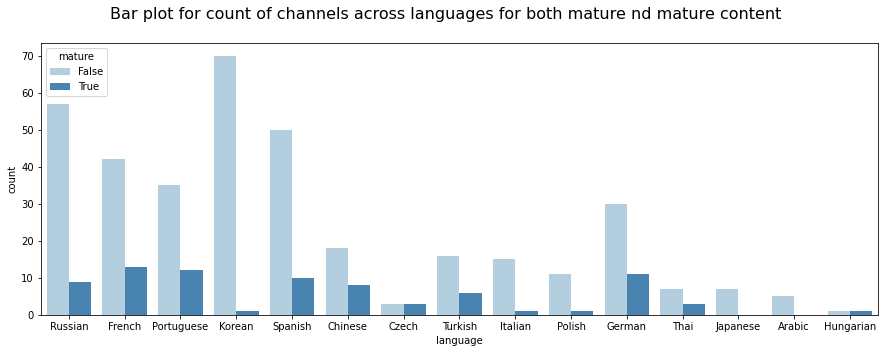

```python
plt.figure(figsize = [15,5])
sb.countplot(data = df3.query('language != "English"'), x = 'language', hue = 'mature', palette = 'Blues');
plt.suptitle('Bar plot for count of channels across languages for both mature nd mature content', fontsize = 16);
```

> Coloring based on type of content with marker sized by watch time in minutes, Average viewers shows positive correlation with watch time for the whole streaming time range. (The most interesting feature was the negative relationship between the streaming time and number of viewers).

[figure not shown]

```python
# scatter plot of followers vs. average viewers and coloring based on type of content with marker sized by watch time in minutes
s = df2.watch_time_minutes/7000000
plt.figure(figsize = [13,8])
plt.scatter(data = df2, x = 'stream_time_minutes', y = 'average_viewers' , c = 'mature', s = s, cmap="Set1", alpha=0.8, edgecolors="grey")
plt.xlabel('stream_time_minutes')
plt.yscale('log')
plt.yticks([500, 1e3, 2e3, 5e3, 1e4, 2e4], [500, '1k', '2k', '5k', '10k', '20k'])
plt.xticks([5e4 , 10e4 ,15e4, 20e4 ,25e4 ], ['50K', '10K', '15k', '20k', '25k'])
plt.suptitle('scatter plot of followers vs. average viewers', fontsize = 16);

plt.ylabel('average_viewers');
```

## Thanks for you attention

for any questions email me at mohannad_m@windowslive.com